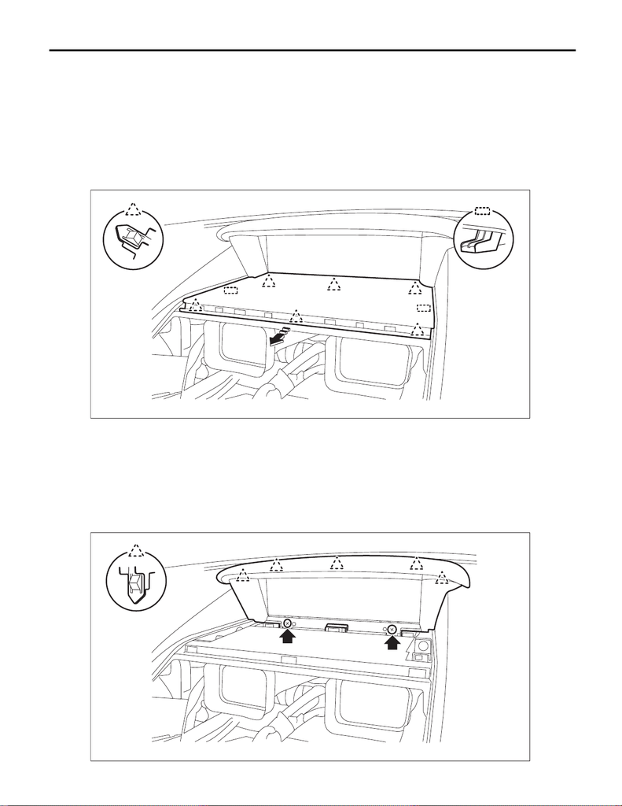

IDI-20

Multi-function Display (MFD)

INSTRUMENTATION/DRIVER INFO

10.Multi-function Display (MFD)

A: REMOVAL

1. MULTI FUNCTION DISPLAY

1) Disconnect the ground cable from battery. <Ref. to NT-5, BATTERY, NOTE, Note.>

NOTE:

For models other than STI model, disconnect the ground terminal from battery sensor.

2) Remove the panel center assembly. <Ref. to EI-66, REMOVAL, Center Console.>

3) Release the claw and hook, and then remove the cover center UPR.

NOTE:

4) Remove the multi-function display.

CAUTION:

Be careful not to damage the multi-function display or instrument panel.

(1) Release the screws and claws.

(2) Pull the multi-function display assembly toward yourself, and disconnect the connector.

EI-03441

EI-03440

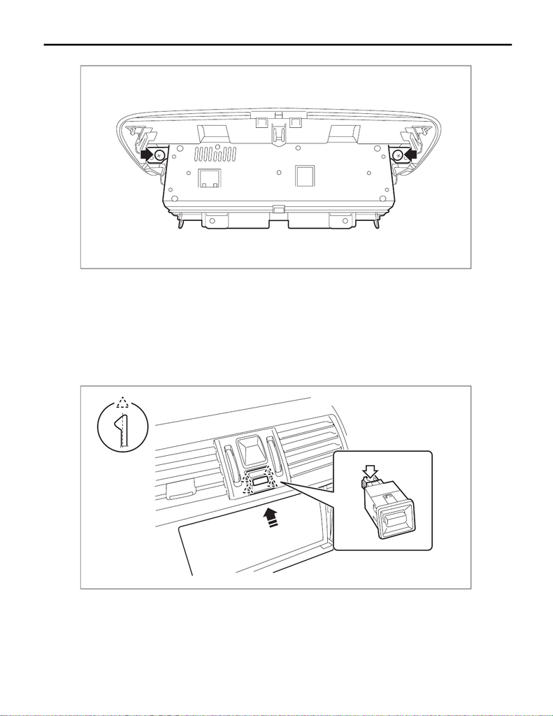

IDI-21

Multi-function Display (MFD)

INSTRUMENTATION/DRIVER INFO

(3) Remove the screws and then remove the multi-function display.

2. MULTI-FUNCTION DISPLAY SWITCH

1) Disconnect the ground cable from battery. <Ref. to NT-5, BATTERY, NOTE, Note.>

NOTE:

For models other than STI model, disconnect the ground terminal from battery sensor.

2) Pull out the panel center assembly. <Ref. to EI-66, REMOVAL, Center Console.>

3) Remove the switch - multi-function display.

(2) Disconnect the connector and remove the switch - multi-function display.

IDI00437

IDI00775

(a)

[figure not shown]

IDI-22

Multi-function Display (MFD)

INSTRUMENTATION/DRIVER INFO

B: INSTALLATION

1. MULTI FUNCTION DISPLAY

CAUTION:

• Make sure the electrical connector is connected securely.

• Make sure that the multi-function display operates normally.

• When the multi-function display has been replaced, perform the following operations.

1) Install the multi-function display.

2) Install the cover center UPR.

3) Install the panel center assembly.

4) Connect the battery ground terminal. <Ref. to NT-5, BATTERY, NOTE, Note.>

NOTE:

For models other than STI model, connect the ground terminal to battery sensor.

2. MULTI-FUNCTION DISPLAY SWITCH

CAUTION:

1) Install the switch - multi-function display.

2) Install the panel center assembly.

3) Connect the battery ground terminal. <Ref. to NT-5, BATTERY, NOTE, Note.>

NOTE:

For models other than STI model, connect the ground terminal to battery sensor.

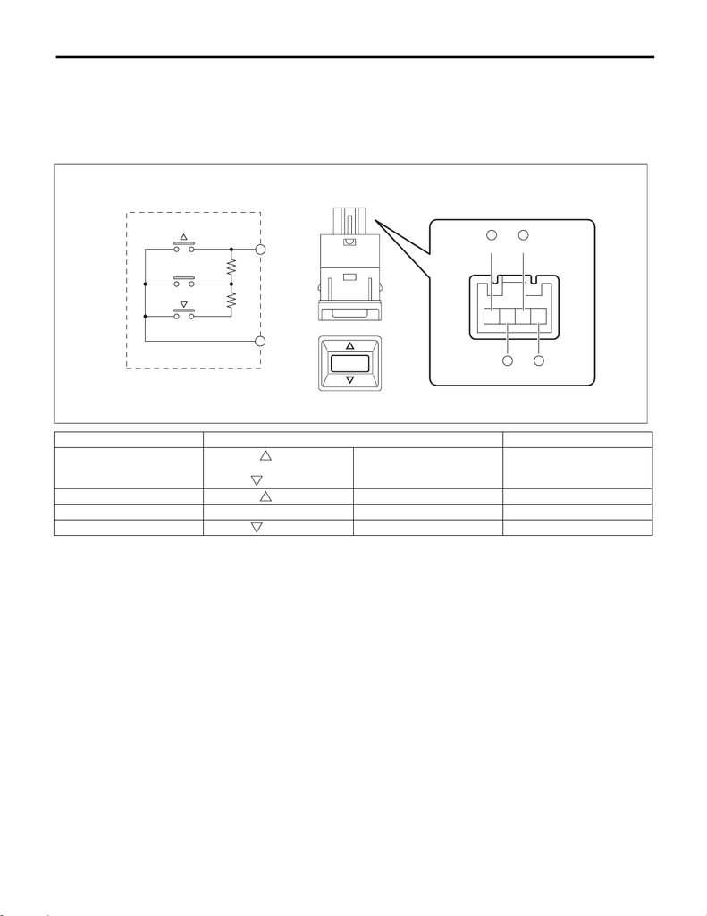

IDI-23

Multi-function Display (MFD)

INSTRUMENTATION/DRIVER INFO

C: INSPECTION

1. MULTI-FUNCTION DISPLAY SWITCH

1) Measure the resistance between connector terminals.

Preparation tool:

Circuit tester

2) If the inspection result is not within the standard, replace the switch - multi-function display.

Terminal No. Inspection conditions Standard

2 — 3

(UP)

ENTER

(DOWN)

All OFF Approx. 1 MΩ or more

2 — 3 (UP) ON Less than 1 Ω

2 — 3 ENTER ON Approx. 1000 Ω

2 — 3 (DOWN) ON Approx. 3670 Ω

IDI00773

ENTER

2

3

ENTER

2

1

MFD -

1

ILL +

3

INTEG U

MFD +